# Homework3

NYC Real Estate Sales Data

Joseph Farrell  
2022-02-16

**Load Libraries**

```r
library(readr)
library(tidyverse)
library(dplyr)
library(mosaic)
library(ggplot2)
```

## Reading in, exploring, and cleaning dataset

**Read in NYC Real Estate Data**

```r
nyc_rolling_sales <- read_csv("/Users/nelsonfarrell/Downloads/nyc-rolling-sales.csv")
```

**Get Column Names**

```r
colnames(nyc_rolling_sales)
```

```
 [1] "...1"                           "BOROUGH"
 [3] "NEIGHBORHOOD"                   "BUILDING CLASS CATEGORY"
 [5] "TAX CLASS AT PRESENT"           "BLOCK"
 [7] "LOT"                            "EASE-MENT"
 [9] "BUILDING CLASS AT PRESENT"      "ADDRESS"
[11] "APARTMENT NUMBER"               "ZIP CODE"
[13] "RESIDENTIAL UNITS"              "COMMERCIAL UNITS"
[15] "TOTAL UNITS"                    "LAND SQUARE FEET"
[17] "GROSS SQUARE FEET"              "YEAR BUILT"
[19] "TAX CLASS AT TIME OF SALE"      "BUILDING CLASS AT TIME OF SALE"
[21] "SALE PRICE"                     "SALE DATE"
```

**View first 6 rows of the dataset**

```r
head(nyc_rolling_sales)
```

```
# A tibble: 6 × 22
   ...1 BOROUGH NEIGHBORHOOD  `BUILDING CLASS…` `TAX CLASS AT …` BLOCK
  <dbl>   <dbl> <chr>         <chr>             <chr>            <dbl>
1     4       1 ALPHABET CITY 07 RENTALS - WAL… 2A                 392
2     5       1 ALPHABET CITY 07 RENTALS - WAL… 2                  399
3     6       1 ALPHABET CITY 07 RENTALS - WAL… 2                  399
4     7       1 ALPHABET CITY 07 RENTALS - WAL… 2B                 402
5     8       1 ALPHABET CITY 07 RENTALS - WAL… 2A                 404
6     9       1 ALPHABET CITY 07 RENTALS - WAL… 2                  405
# … with 16 more variables: LOT <dbl>, `EASE-MENT` <lgl>,
#   `BUILDING CLASS AT PRESENT` <chr>, ADDRESS <chr>,
#   `APARTMENT NUMBER` <chr>, `ZIP CODE` <dbl>,
#   `RESIDENTIAL UNITS` <dbl>, `COMMERCIAL UNITS` <dbl>,
#   `TOTAL UNITS` <dbl>, `LAND SQUARE FEET` <chr>,
#   `GROSS SQUARE FEET` <chr>, `YEAR BUILT` <dbl>,
#   `TAX CLASS AT TIME OF SALE` <dbl>, …
```

**Check the variables in the dataset**

```r
str(nyc_rolling_sales)
```

```
spec_tbl_df [84,548 × 22] (S3: spec_tbl_df/tbl_df/tbl/data.frame)
 $ ...1                          : num [1:84548] 4 5 6 7 8 9 10 11 12 13 ...
 $ BOROUGH                       : num [1:84548] 1 1 1 1 1 1 1 1 1 1 ...
 $ NEIGHBORHOOD                  : chr [1:84548] "ALPHABET CITY" "ALPHABET CITY" "ALPHABET CITY" "ALPHABET CITY" ...
 $ BUILDING CLASS CATEGORY       : chr [1:84548] "07 RENTALS - WALKUP APARTMENTS" "07 RENTALS - WALKUP APARTMENTS" "07 RENTALS - WALKUP APARTMENTS" "07 RENTALS - WALKUP APARTMENTS" ...
 $ TAX CLASS AT PRESENT          : chr [1:84548] "2A" "2" "2" "2B" ...
 $ BLOCK                         : num [1:84548] 392 399 399 402 404 405 406 407 379 387 ...
 $ LOT                           : num [1:84548] 6 26 39 21 55 16 32 18 34 153 ...
 $ EASE-MENT                     : logi [1:84548] NA NA NA NA NA NA ...
 $ BUILDING CLASS AT PRESENT     : chr [1:84548] "C2" "C7" "C7" "C4" ...
 $ ADDRESS                       : chr [1:84548] "153 AVENUE B" "234 EAST 4TH   STREET" "197 EAST 3RD   STREET" "154 EAST 7TH STREET" ...
 $ APARTMENT NUMBER              : chr [1:84548] NA NA NA NA ...
 $ ZIP CODE                      : num [1:84548] 10009 10009 10009 10009 10009 ...
 $ RESIDENTIAL UNITS             : num [1:84548] 5 28 16 10 6 20 8 44 15 24 ...
 $ COMMERCIAL UNITS              : num [1:84548] 0 3 1 0 0 0 0 2 0 0 ...
 $ TOTAL UNITS                   : num [1:84548] 5 31 17 10 6 20 8 46 15 24 ...
 $ LAND SQUARE FEET              : chr [1:84548] "1633" "4616" "2212" "2272" ...
 $ GROSS SQUARE FEET             : chr [1:84548] "6440" "18690" "7803" "6794" ...
 $ YEAR BUILT                    : num [1:84548] 1900 1900 1900 1913 1900 ...
 $ TAX CLASS AT TIME OF SALE     : num [1:84548] 2 2 2 2 2 2 2 2 2 2 ...
 $ BUILDING CLASS AT TIME OF SALE: chr [1:84548] "C2" "C7" "C7" "C4" ...
 $ SALE PRICE                    : chr [1:84548] "6625000" "-" "-" "3936272" ...
 $ SALE DATE                     : POSIXct[1:84548], format: "2017-07-19" ...
 - attr(*, "spec")=
  .. cols(
  ..   ...1 = col_double(),
  ..   BOROUGH = col_double(),
  ..   NEIGHBORHOOD = col_character(),
  ..   `BUILDING CLASS CATEGORY` = col_character(),
  ..   `TAX CLASS AT PRESENT` = col_character(),
  ..   BLOCK = col_double(),
  ..   LOT = col_double(),
  ..   `EASE-MENT` = col_logical(),
  ..   `BUILDING CLASS AT PRESENT` = col_character(),
  ..   ADDRESS = col_character(),
  ..   `APARTMENT NUMBER` = col_character(),
  ..   `ZIP CODE` = col_double(),
  ..   `RESIDENTIAL UNITS` = col_double(),
  ..   `COMMERCIAL UNITS` = col_double(),
  ..   `TOTAL UNITS` = col_double(),
  ..   `LAND SQUARE FEET` = col_character(),
  ..   `GROSS SQUARE FEET` = col_character(),
  ..   `YEAR BUILT` = col_double(),
  ..   `TAX CLASS AT TIME OF SALE` = col_double(),
  ..   `BUILDING CLASS AT TIME OF SALE` = col_character(),
  ..   `SALE PRICE` = col_character(),
  ..   `SALE DATE` = col_datetime(format = "")
  .. )
 - attr(*, "problems")=<externalptr>
```

**Change “SALE PRICE” to Numeric Variable**

```r
nyc_rolling_sales$`SALE PRICE` <- as.numeric(nyc_rolling_sales$`SALE PRICE`)
```

**Change borough code numbers into borough names “Manhatten”, “Queens”, etc.** *In the dataset the different boroughs of New York City were represented with numbers 1-5, 1 Manhatten, 2 the Bronx, etc…*

```r
nyc_rolling_sales <- mutate(nyc_rolling_sales, BOROUGH = recode(BOROUGH, `1` = "Manhatten",
    `2` = "Bronx", `3` = "Brooklyn", `4` = "Queens", `5` = "Staten Island"))
```

**Recode “BUILDING CLASS” to be more descriptive** *The building classes in the data were coded. Here I will recode R1-R4, essentially all the single unit residential properties in the dataset*

```r
nyc_rolling_sales <- mutate(nyc_rolling_sales, `BUILDING CLASS AT PRESENT` = recode(`BUILDING CLASS AT PRESENT`,
    `R4` = "Condo Elevator Building", `R3` = "Condo 1 to 3 Stories ",
    `R2` = "Condo Walkup", `R1` = "Condo 2 to 10 Unit Building"))
```

**Select columns “BOROUGH”, “NEIGHBORHOOD”, “BUILDING CLASS AT PRESENT”, “RESIDENTIAL UNITS”, “GROSS SQUARE FEET”, “SALE PRICE”, “SALE DATE”** *Not all of the variables will be useful for my planned analysis, this removes those that I do not plan use*

```r
nyc_rolling_sales <-select(nyc_rolling_sales, "BOROUGH", "NEIGHBORHOOD", "BUILDING CLASS AT PRESENT",
    "RESIDENTIAL UNITS", "GROSS SQUARE FEET", "SALE PRICE", "SALE DATE")
```

**Rename columns “BUILDING CLASS AT PRESENT”, and “RESIDENTIAL UNITS”** *This changes the names of some of the columns for clarity, “Residential Units” will become “Units” because I will only be looking at Residential Units. “BUILDING CLASS AT PRESENT” will become simply "BUILDING CLASS*

```r
nyc_rolling_sales <- rename(nyc_rolling_sales, "BUILDING CLASS" = "BUILDING CLASS AT PRESENT",
    "SQ FOOTAGE" = "GROSS SQUARE FEET", "UNITS" = "RESIDENTIAL UNITS")
```

**Remove all observations that do not contain a residential unit, and all sale prices under $100,000 and over $5,000,000** *There were a lot very low prices that according to data description could indicate family member to family member transfer, i.e., inheritance. The data is also heavily skewed to the right, so I will look at only specific range of prices (i.e., $100,000-$5,000,000)*

```r
nyc_rolling_sales <- filter(nyc_rolling_sales, ! `UNITS` == "0" & ! `SALE PRICE` == "-" &
    `SALE PRICE` > 100000 & `SALE PRICE` < 5000000)
arrange(nyc_rolling_sales, `SALE PRICE`)
```

```
# A tibble: 37,897 × 7
   BOROUGH       NEIGHBORHOOD      `BUILDING CLASS` UNITS `SQ FOOTAGE`
   <chr>         <chr>             <chr>            <dbl> <chr>
 1 Staten Island MIDLAND BEACH     "A6"                 1 588
 2 Brooklyn      PARK SLOPE SOUTH  "C0"                 3 2781
 3 Queens        FLUSHING-SOUTH    "Condo 1 to 3 S…     1 -
 4 Queens        JAMAICA           "S2"                 2 3225
 5 Bronx         MELROSE/CONCOURSE "C0"                 3 3972
 6 Brooklyn      BOERUM HILL       "Condo Elevator…     1 0
 7 Bronx         PARKCHESTER       "Condo Elevator…     1 0
 8 Bronx         PARKCHESTER       "Condo Elevator…     1 0
 9 Queens        REGO PARK         "B3"                 2 2128
10 Bronx         PARKCHESTER       "Condo Elevator…     1 0
# … with 37,887 more rows, and 2 more variables: `SALE PRICE` <dbl>,
#   `SALE DATE` <dttm>
```

```r
head(nyc_rolling_sales)
```

```
# A tibble: 6 × 7
  BOROUGH   NEIGHBORHOOD  `BUILDING CLASS`        UNITS `SQ FOOTAGE`
  <chr>     <chr>         <chr>                   <dbl> <chr>
1 Manhatten ALPHABET CITY C4                         10 6794
2 Manhatten ALPHABET CITY C4                          8 4226
3 Manhatten ALPHABET CITY Condo Walkup                1 -
4 Manhatten ALPHABET CITY Condo Elevator Building     1 -
5 Manhatten ALPHABET CITY Condo Elevator Building     1 -
6 Manhatten ALPHABET CITY Condo Elevator Building     1 -
# … with 2 more variables: `SALE PRICE` <dbl>, `SALE DATE` <dttm>
```

**Identify and view the different types of building classes** *Each of these identifiers is defined in the description of the dataset, R4s (“Condo; Residential Unit in Elevator Building”) are the most numerous. It will be most revealing to compare like dwellings so I have renamed R1-R4, and I will filter out the rest*

```r
tally(~ `BUILDING CLASS`, data = nyc_rolling_sales)
```

```
BUILDING CLASS
                         A0                          A1
                        307                        4666
                         A2                          A3
                       1895                         238
                         A4                          A5
                         91                        4023
                         A6                          A7
                         62                           2
                         A9                          B1
                        949                        2718
                         B2                          B3
                       3124                        2437
                         B9                          C0
                        918                        2245
                         C1                          C2
                        267                         369
                         C3                          C4
                        538                          46
                         C5                          C6
                         63                           7
                         C7                          C9
                         66                           5
      Condo 1 to 3 Stories  Condo 2 to 10 Unit Building
                       1076                         934
    Condo Elevator Building                Condo Walkup
                       8931                         646
                         D1                          D3
                         11                           3
                         D4                          D6
                         24                           6
                         D7                          D9
                          2                           2
                         E9                          F9
                          2                           2
                         G0                          G4
                          7                           1
                         G9                          HR
                          1                           2
                         I7                          K1
```

[output cut: 12 more lines]

```
                         18                           2
                         R6                          RR
                        129                           9
                         S0                          S1
                          7                         202
                         S2                          S3
                        403                          79
                         S4                          S5
                         61                          50
                         S9                          V0
                         96                          28
                         V1                          W2
                          3                           1
                         Z0                          Z9
                          1                           1
```

**Filter “Building Class” for “Condo Elevator Building”, previously “R4”** *Here I have filtered for just “Condo Elevator Building”*

```r
nyc_rolling_sales<- filter(nyc_rolling_sales, `BUILDING CLASS` == "Condo Elevator Building")
head(nyc_rolling_sales)
```

```
# A tibble: 6 × 7
  BOROUGH   NEIGHBORHOOD  `BUILDING CLASS`        UNITS `SQ FOOTAGE`
  <chr>     <chr>         <chr>                   <dbl> <chr>
1 Manhatten ALPHABET CITY Condo Elevator Building     1 -
2 Manhatten ALPHABET CITY Condo Elevator Building     1 -
3 Manhatten ALPHABET CITY Condo Elevator Building     1 -
4 Manhatten ALPHABET CITY Condo Elevator Building     1 -
5 Manhatten ALPHABET CITY Condo Elevator Building     1 -
6 Manhatten ALPHABET CITY Condo Elevator Building     1 -
# … with 2 more variables: `SALE PRICE` <dbl>, `SALE DATE` <dttm>
```

## The Variables in the dataset after cleaning the data

- **BOROUGH**: Character, this identifies which borough of New York City the property is in.
- **NEIGHBORHOOD**: Character, this identifies the specific neighborhood within each borough that the property is in.
- **BUILDING CLASS**: Character, this identifies what type of building the property is.
- **UNITS**: Numeric, this identifies the number of units in the property
- **SQ FOOTAGE**: Character, still currently character although I will change it numeric if it turns out to be useful. Displays the total area of the property, inside and out, in square feet
- **SALE PRICE**: Numeric, this is the sale price of the property
- **SALE DATE**: Numeric, this is the date the property was sold.

## Exploratory analyiss

**Create Object “Brooklyn_1” for property sales of “CONDO ELEVATOR BUILDINGs” in Brooklyn**

```r
Brooklyn_1 <- filter(nyc_rolling_sales, `BOROUGH` == "Brooklyn")
```

**Create Object “Manhatten_1” for property sales of “CONDO ELEVATOR BUILDINGs” in Manhatten**

```r
Manhatten_1 <- filter(nyc_rolling_sales, `BOROUGH` == "Manhatten")
```

**Display Boxplot of “SALE PRICE” of “CONDO ELEVATOR BUILDINGS” in Brooklyn & Manhatten** *Here we can still clearly see that even after looking at only a range of the “SALE PRICE” the data is still heavily skewed to the right with numerous outliers. As a result, I will use median as a measure of center.*

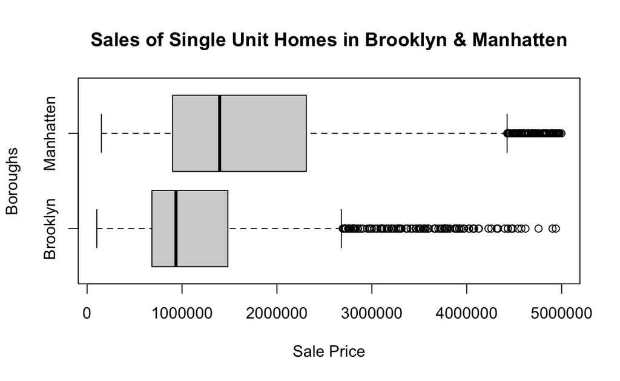

```r
options(scipen = 999) ##Remove Scientific Notation
boxplot(Brooklyn_1$`SALE PRICE`, Manhatten_1$`SALE PRICE`, horizontal = TRUE, names=c("Brooklyn", "Manhatten"),
    main = "Sales of Single Unit Homes in Brooklyn & Manhatten", ylab = "Boroughs", xlab = "Sale Price")
```

**Display summary statistics of “Brooklyn_1” and “SALE PRICE” and “Manhatten_1” and “SALE PRICE”**

```r
favstats(Brooklyn_1$`SALE PRICE`)
```

```
    min     Q1 median      Q3     max    mean       sd    n missing
 101825 682227 936270 1482500 4938512 1206647 806376.9 2159       0
```

```r
favstats(Manhatten_1$`SALE PRICE`)
```

```
    min     Q1  median      Q3     max    mean      sd    n missing
 150000 900000 1396500 2310000 4996841 1734470 1074408 4783       0
```

**Find the median “SALE PRICE” of “CONDO ELEVATOR BUILDINGs” in each of the five New York City “BOROUGHS”**

```r
nyc_rolling_sales %>%
  group_by(BOROUGH) %>%
  select("SALE PRICE") %>%
  summarize_all(median, na.rm = TRUE)
```

```
# A tibble: 5 × 2
  BOROUGH       `SALE PRICE`
  <chr>                <dbl>
1 Bronx               143500
2 Brooklyn            936270
3 Manhatten          1396500
4 Queens              643000
5 Staten Island       240318
```

**Find the median “SALE PRICE” of “CONDO ELEVATOR BUILDINGs” in each of the different Manhatten “NEIGHBORHOODs”**

```r
Manhatten_1 %>%
  group_by(NEIGHBORHOOD) %>%
  select("SALE PRICE") %>%
  summarize_all(median, na.rm = TRUE)
```

```
# A tibble: 38 × 2
   NEIGHBORHOOD  `SALE PRICE`
   <chr>                <dbl>
 1 ALPHABET CITY     1310000
 2 CHELSEA           1820000
 3 CHINATOWN         1440000
 4 CIVIC CENTER      3250000
 5 CLINTON           1236250
 6 EAST VILLAGE      1285000
 7 FASHION           1735000
 8 FINANCIAL         1450000
 9 FLATIRON          2300000
10 GRAMERCY          1834270.
# … with 28 more rows
```

## Potential Research Questions

- Which BOROUGH has the highest median property value?
- Which NEIGHBORHOODs within each BOROUGH have the highest median property value?
- Which BOROUGH’s median property value is increasing (decreasing) the fastest?
  - In which BOROUGH would it make the most financial sense to purchase an investment property?
- Which NEIGHBORHOOD’s property value is increasing (decreasing) the fastest?
  - In which NEIGHBORHOOD would it make the most financial sense to purchase an investment property?
- Are there correlations between property values in BOROUGHs and/or NEIGHBORHOODs?
- Determine and examine price per square foot as a metric. (Unclear if this is possible as this data is missing from many of the observations)